# Sesgo-Varianza, kNN, Cross-Validation

Ciencia de Datos para Políticas Públicas

Pablo Aguirre Hörmann

# Resumen

Este documento utiliza datos de casas en Boston (USA) para ilustrar lo siguiente:

- El algoritmo **$k$-Nearest Neighbors** (**kNN**);
- El intercambio **Sesgo-Varianza**; y
- El uso de **Cross Validation** para estimar el error de predicción (fuera de muestra) y determinar el hiperparámetro óptimo, en este caso el número de “vecinos cercanos” $k$.

# Paquetes y datos

Observemos los datos disponibles.

```r
library(tidyverse)
library(MASS)
library(kknn)
glimpse(Boston)
```

```
## Rows: 506
## Columns: 14
## $ crim    <dbl> 0.00632, 0.02731, 0.02729, 0.03237, 0.06905, 0.02985, 0.088...
## $ zn      <dbl> 18.0, 0.0, 0.0, 0.0, 0.0, 0.0, 12.5, 12.5, 12.5, 12.5, 12.5...
## $ indus   <dbl> 2.31, 7.07, 7.07, 2.18, 2.18, 2.18, 7.87, 7.87, 7.87, 7.87,...
## $ chas    <int> 0, 0, 0, 0, 0, 0, 0, 0, 0, 0, 0, 0, 0, 0, 0, 0, 0, 0, 0, 0,...
## $ nox     <dbl> 0.538, 0.469, 0.469, 0.458, 0.458, 0.458, 0.524, 0.524, 0.5...
## $ rm      <dbl> 6.575, 6.421, 7.185, 6.998, 7.147, 6.430, 6.012, 6.172, 5.6...
## $ age     <dbl> 65.2, 78.9, 61.1, 45.8, 54.2, 58.7, 66.6, 96.1, 100.0, 85.9...
## $ dis     <dbl> 4.0900, 4.9671, 4.9671, 6.0622, 6.0622, 6.0622, 5.5605, 5.9...
## $ rad     <int> 1, 2, 2, 3, 3, 3, 5, 5, 5, 5, 5, 5, 5, 4, 4, 4, 4, 4, 4, 4,...
## $ tax     <dbl> 296, 242, 242, 222, 222, 222, 311, 311, 311, 311, 311, 311,...
## $ ptratio <dbl> 15.3, 17.8, 17.8, 18.7, 18.7, 18.7, 15.2, 15.2, 15.2, 15.2,...
## $ black   <dbl> 396.90, 396.90, 392.83, 394.63, 396.90, 394.12, 395.60, 396...
## $ lstat   <dbl> 4.98, 9.14, 4.03, 2.94, 5.33, 5.21, 12.43, 19.15, 29.93, 17...
## $ medv    <dbl> 24.0, 21.6, 34.7, 33.4, 36.2, 28.7, 22.9, 27.1, 16.5, 18.9,...
```

Nos enfocaremos en usar la variable `lstat` para predecir `medv`. Primero graficamos ambas variables:

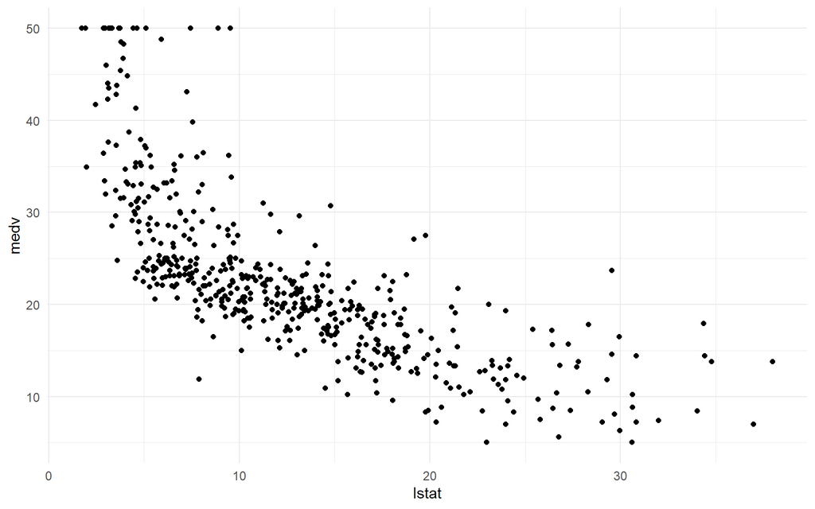

```r
Boston %>%
  ggplot(aes(x = lstat, y = medv)) +
  geom_point() +
  theme_minimal()
```

# Algoritmo $k$-Nearest Neighbors (knn) y dilema sesgo-varianza

Primero estimaremos un modelo KNN usando $k$ = 5 con todos los datos disponibles:

```r
knn_model_5 <- kknn(medv ~ lstat,
                  train = Boston, test = Boston,
                  k = 5, kernel='rectangular')
```

Crearemos una función para graficar los resultados ya que realizaremos esta misma acción unas veces más.

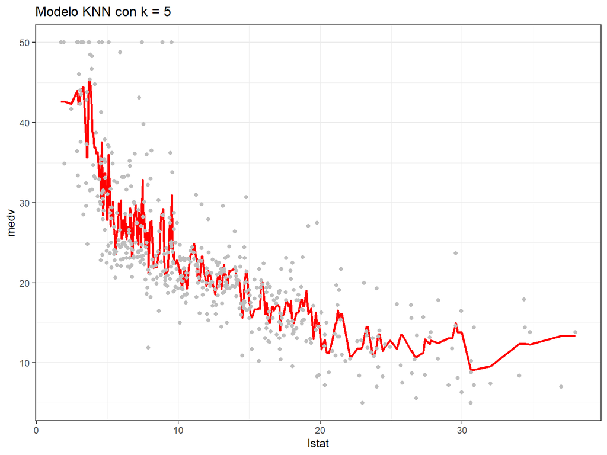

```r
knn_model_5 <- kknn(medv ~ lstat,
                  train = Boston, test = Boston,
                  k = 5, kernel='rectangular')

plot_knn <- function(modelo, titulo){

  ggplot(data = Boston, aes(x = lstat, y = medv)) +
  geom_line(aes(x = lstat, y = modelo$fitted.values), col = "red", size = 1) +
  geom_point(col = "grey") +
  theme_bw() +
  labs(title = titulo)

}

plot_knn(modelo = knn_model_5, titulo = "Modelo KNN con k = 5")
```

Con $k$ = 5, un número bajo, tenemos una curva con muchos “saltos” que **ajusta bien los datos de entrenamiento** pero que es **muy sensible a pequeños cambios** en la variable `lstat`. Este es un modelo con **BAJO SESGO** y **ALTA VARIANZA**. No es un modelo que nos gusta.

Tratemos ahora con $k$ = 300.

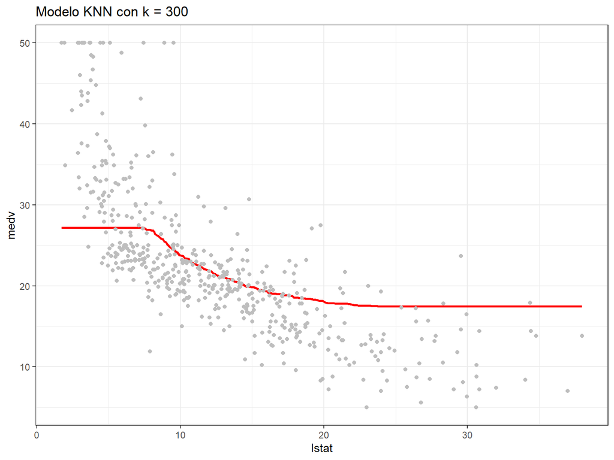

```r
knn_model_300 <- kknn(medv ~ lstat,
                      train = Boston, test = Boston,
                      k = 300, kernel='rectangular')

plot_knn(modelo = knn_model_300, titulo = "Modelo KNN con k = 300")
```

En este caso parece que nos fuimos a otro extremo. La linea parece ser **no extremadamente sensible**, pero también **muy simple y “suave”**. En otras palabras, **no responde lo suficiente** a cambios en la variable `lstat`. En este caso decimos que tenemos **ALTO SESGO Y BAJA VARIANZA**.

Por último, intentemos algo intermedio como $k$ = 50.

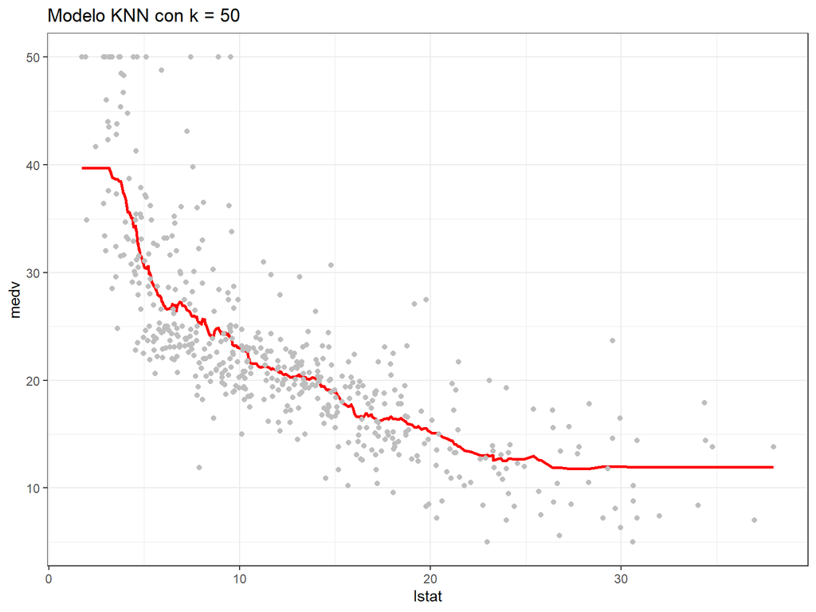

```r
knn_model_50 <- kknn(medv ~ lstat,
                      train = Boston, test = Boston,
                      k = 50, kernel='rectangular')

plot_knn(modelo = knn_model_50, titulo = "Modelo KNN con k = 50")
```

Esto pareciera ser más razonable y podríamos decir que la curva **es una buena generalización** de la relación entre ambas variables. A esta curva o modelo lo llamarías de **bajo sesgo y baja varianza**. A esto es a lo que queremos llegar.

Entonces, el mensaje principal es que a lo largo de un rango de **hyper-parameter** $k$ de más pequeño a más grande, vemos un espectro de modelos que van desde “bajo sesgo y alta varianza” a “alto sesgo y baja varianza”. A este fenómeno se le conoce como el **DILEMA SESGO-VARIANZA**, un concepto fundamental en *Machine Learning* y que aplica no solo a los modelos KNN sino que a todo tipo de modelos.

El dilema sesgo-varianza tiene relación con la **generalización de un modelo predictivo** cuando se ve enfrentado a datos con los cuales no fue entrenado/estimado. Si un modelo tiene alto sesgo o alta varianza no le irá bien con observaciones nuevas. Un buen modelo necesita tener la perfecta combinación de **bajo sesgo y baja varianza**.

# Error fuera de muestra y Cross-Validaton

Para **cuantificar que tan bueno es un modelo predictivo**, necesitamos estimar el **error de predicción fuera de muestra**. En otras palabras, **medir que tan bien predice un modelo en datos que no fueorn usados para su entrenamiento/estimación**.

```r
# Definir el máximo de valores de "k" a probar
rango_k <- 200

# Definir el número de "folds"
fold <- 10

# Asignar a cada observación un "fold"
Boston <- Boston %>%
  mutate(fold = c(rep(1:fold, 50), 1:6))

# Vector que guarda los resultados del error de predicción para cada "k"
error_total <- vector(length = rango_k)

# Iteración para cada valor de "k"
for (i in 1:rango_k){

  # Vector que guarda los resultados de error para cada "fold"
  error <- vector(length = fold)

  # Iteración para cada "fold"
  for (j in 1:fold){

    # Definir grupos de entrenamiento y test
    train <- Boston %>%
      filter(fold != j)
    test <- Boston %>%
      filter(fold == j)

    # Estimar modelo
    knn_model <- kknn(medv ~ lstat,
                      train = train, test = test,
                      k = i, kernel='rectangular')

    # Almacenar error del "fold"
    error[j] <- mean(sqrt((knn_model$fitted.values - test$medv)^2))
  }

  # Almacenar error para cada valor de "k"
  error_total[i] <- mean(error)

}
```

Calcularemos también el error de predicción “dentro de muestra”.

```r
error_total_dentro <- vector(length = rango_k)

for (i in 1:rango_k){

  knn_model <- kknn(medv ~ lstat,
                    train = Boston, test = Boston,
                    k = i, kernel='rectangular')

  error_total_dentro[i] <- mean(sqrt((knn_model$fitted.values - Boston$medv)^2))

}
```

A continuación graficamos el error de predicción dentro y fuera de muestra como función del valor de $k$. El eje x en este caso es $-log(k)$ con el fin de que yendo de izquierda a derecha se pueda leer como “de menos a más complejo/flexible”.

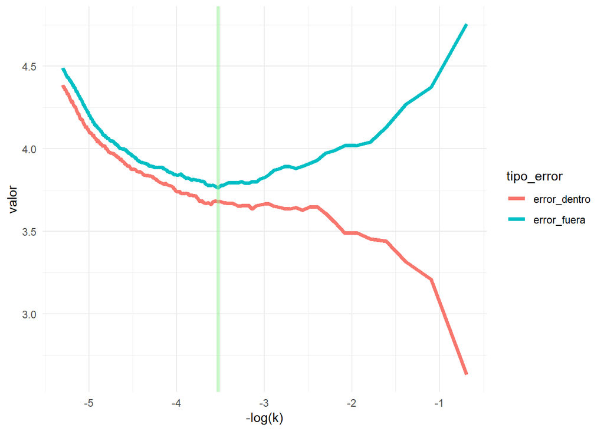

```r
errores_dentro_muestra <- error_total_dentro %>%
  as_tibble() %>%
  rename(error_dentro = value) %>%
  mutate(k = 1:rango_k)

errores_fuera_muestra <- error_total %>%
  as_tibble() %>%
  rename(error_fuera = value) %>%
  mutate(k = 1:rango_k)

datos_errores <- errores_fuera_muestra %>%
  left_join(errores_dentro_muestra, by = "k") %>%
  relocate(k, .before = error_fuera) %>%
  pivot_longer(2:3, names_to = "tipo_error", values_to = "valor") %>%
  filter(k >= 2)

datos_errores %>%
  ggplot(aes(x = -log(k), y = valor, col = tipo_error)) +
  geom_line(size = 1.5) +
  geom_vline(xintercept = -log(which.min(error_total)), alpha = 0.5, col = "light green", size = 1.3) +
  theme_minimal()
```

Se puede ver claramente como el error de predicción dentro de muestra tiende a disminuir siempre con el aumento en la complejidad/flexibilidad del modelo (menores valores de $k$) mientras que el error fuera de muestra llega a un mínimo y luego comienza a subir. El valor mínimo al que se llega corresponde a un valor de $k$ de 34 y es entonces el valor de complejidad/flexibilidad con el que se alcanza el menor error de predicción.